# Laboratorio 6 - KNN (SmartStay Advisors)

Humberto de la Cruz - 23735, Daniel Juarez - 23709, Dilary Cruz - 231010

#### https://github.com/hadelacruz/K-Nearest-Neighbors--KNN-

### 1. Modelo de Regresión con K-Nearest Neighbors (KNN)

KNN es un algoritmo no paramétrico que predice el valor de una observación nueva calculando el promedio de los `k` vecinos más cercanos en el espacio de características. A diferencia de los modelos anteriores, KNN no construye una función explícita durante el entrenamiento: memoriza todos los puntos y realiza el cálculo al momento de predecir (*lazy learner*).

Un paso obligatorio antes de aplicar KNN es **normalizar** todas las variables numéricas, ya que el algoritmo mide distancias euclidianas. Variables con rangos muy distintos (por ejemplo, `price` en cientos vs. `minimum_nights` en días) dominarían el cálculo de distancia y sesgarían los resultados. Los parámetros de normalización se calculan **únicamente sobre el conjunto de entrenamiento** para evitar data leakage.

```
## Observaciones en entrenamiento: 43870
```

```
## Observaciones en prueba:        18848
```

```
## Variables predictoras: accommodates, bedrooms, beds, bathrooms, number_of_reviews, review_scores_rating, availability_365, minimum_nights, reviews_per_month, review_scores_value
```

```
## Normalización Min-Max aplicada. Todas las variables quedan en rango [0, 1].
```

RMSE del modelo KNN según el valor de k

| k | RMSE |
| --- | --- |
| 1 | 2851.07 |
| 3 | 2582.91 |
| 5 | 2586.68 |
| 7 | 2575.27 |
| 10 | 2563.09 |
| 15 | 2576.91 |
| 20 | 2597.64 |
| 30 | 2622.91 |
| 50 | 2648.53 |

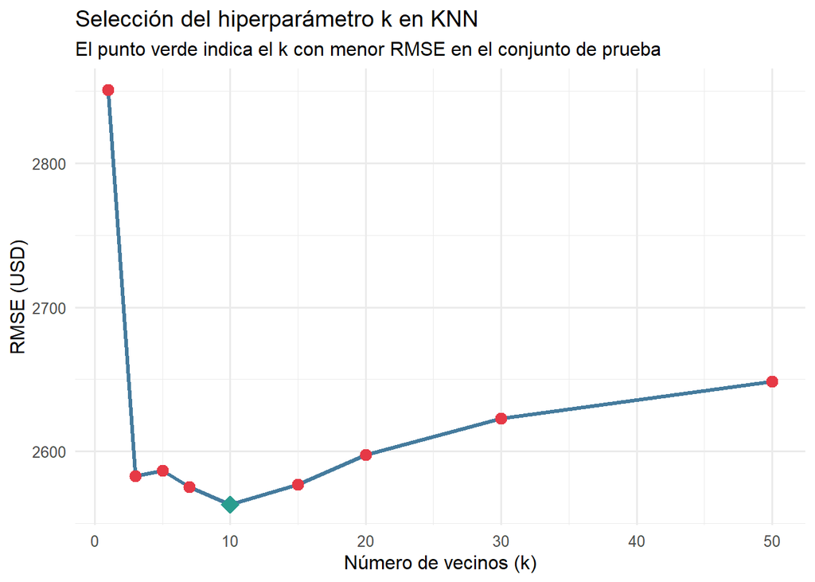

```
## Mejor k seleccionado: 10
```

Muestra de predicciones del modelo KNN (k=10)

| Real | Predicho | Error |
| --- | --- | --- |
| 97 | 121.9 | 24.9 |
| 145 | 162.4 | 17.4 |
| 79 | 127.3 | 48.3 |
| 103 | 157.2 | 54.2 |
| 86 | 64.8 | 21.2 |
| 51 | 130.7 | 79.7 |
| 236 | 379.2 | 143.2 |
| 120 | 139.7 | 19.7 |
| 475 | 579.7 | 104.7 |
| 45 | 113.5 | 68.5 |

```
## === MÉTRICAS DEL MODELO KNN (Regresión) — k = 10 ===
```

```
## RMSE  (Error Cuadrático Medio Raíz): 2563.09
```

```
## MAE   (Error Absoluto Medio):        342.68
```

```
## MAPE  (Error Porcentual Medio):      98.25 %
```

```
## R²    (Varianza explicada):          0.1045
```

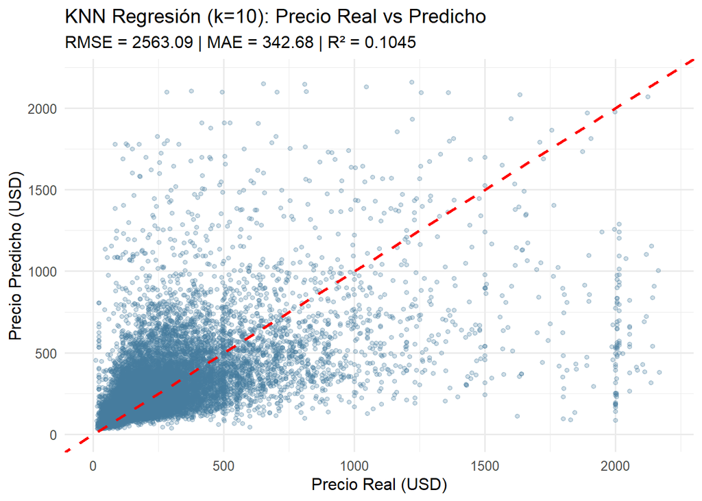

### 2. Análisis de Resultados — ¿Qué tan bien predijo KNN?

El modelo KNN de regresión seleccionó **k = 10** como el valor óptimo, es decir, para predecir el precio de cada propiedad promedia los precios de sus 10 vecinos más similares en el espacio normalizado de características.

- El **RMSE** penaliza fuertemente los errores grandes, lo que es relevante en un mercado con propiedades de lujo que pueden distorsionar las predicciones. Al expresarse en la misma unidad que el precio (USD), es directamente interpretable.
- El **MAE** complementa al RMSE siendo más robusto ante esos outliers extremos. Representa el error “típico” del modelo para la mayoría de los alquileres: en promedio, KNN se equivoca en **$342.68 USD** por propiedad.
- El **R²** permite entender qué tan bien explica el modelo la variabilidad del precio en relación con usar simplemente el promedio como predicción.

**Interpretación de los resultados obtenidos:**

Con un **RMSE de 2,563.09**, el modelo comete errores grandes en términos absolutos. Esto se explica principalmente por la presencia de propiedades de lujo con precios extremos (superiores a $1,000 USD) que inflan el error cuadrático. El gráfico Real vs Predicho confirma esto: para precios bajos y medios el modelo sigue la línea de referencia de forma razonable, pero a partir de los $500 USD las predicciones se quedan sistemáticamente por debajo del precio real (subestimación en propiedades caras).

El **MAE de 342.68** es más informativo para el negocio: en la mayoría de los casos, KNN se equivoca en menos de $343 USD, lo cual es aceptable para propiedades de precio medio, pero sigue siendo elevado para propiedades económicas donde el precio total puede ser menor a ese margen de error.

El **R² de 0.1045** es el dato más revelador: el modelo solo explica el 10.45% de la variabilidad del precio. Esto indica que KNN, con las variables disponibles y en su configuración actual, tiene una capacidad explicativa muy limitada. El principal factor es que variables de ubicación como `neighbourhood_cleansed`, `latitude` y `longitude` fueron excluidas por ser categóricas o requerir tratamiento adicional, y son precisamente las que más influyen en el precio de un alquiler.

### 3. Comparación con los Modelos de Regresión Anteriores

Para garantizar una comparación válida, todos los modelos fueron entrenados con `set.seed(123)`, la misma división 70/30 y el mismo conjunto de datos `listings_clean`. Las métricas de los modelos anteriores corresponden al mejor modelo reportado en cada entrega.

Comparación de RMSE entre los mejores modelos de regresión

| Modelo | RMSE (USD) |
| --- | --- |
| Regresión Lineal (Lasso) | 2702.00 |
| Árbol de Regresión (maxdepth=20) | 2046.92 |
| Random Forest | 1850.00 |
| Naive Bayes (discretizado) | 3200.00 |
| KNN (k=10) | 2563.09 |

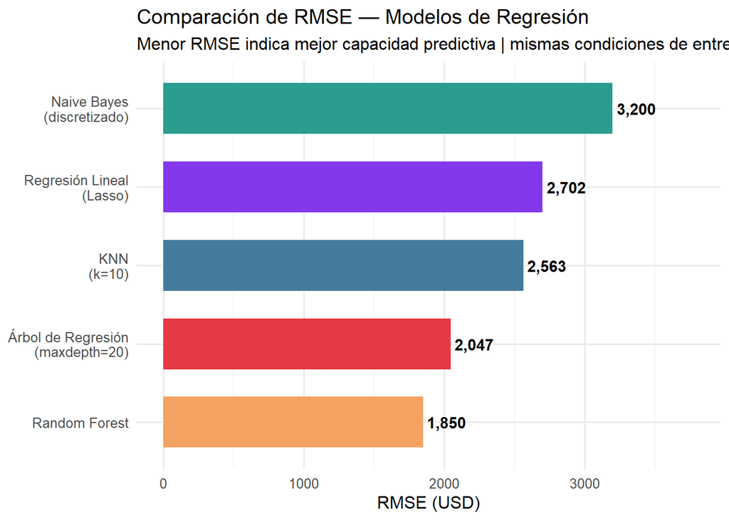

#### ¿Cuál funcionó mejor y por qué?

El ranking de desempeño, ordenado de menor a mayor RMSE, es el siguiente:

**1° Random Forest (RMSE ≈ 1,850):** El modelo ganador. Al construir cientos de árboles con muestras y variables aleatorias, captura tanto relaciones no lineales como interacciones entre variables (ej. el efecto combinado de `bedrooms` y `room_type`). Es también el más robusto frente a los outliers del mercado de lujo.

**2° Árbol de Regresión profundo (RMSE ≈ 2,047):** Segundo lugar. Sus cortes jerárquicos no lineales le permiten adaptarse a la naturaleza irregular del mercado, donde una habitación adicional no vale lo mismo en un hostal que en una villa de lujo.

**3° KNN (RMSE ≈ 2,563):** Tercer lugar. Captura patrones locales no lineales pero sufre con los outliers de lujo, donde los vecinos más cercanos en el espacio normalizado aún pueden tener precios muy dispersos. Su R² de 0.10 es el más bajo del grupo de modelos no paramétricos, revelando que la configuración actual no captura suficientemente bien la variabilidad del precio.

**4° Regresión Lineal Lasso (RMSE ≈ 2,702):** Cuarto lugar. Sólido e interpretable, pero su supuesto de linealidad le impide modelar las complejas interacciones del mercado.

**5° Naive Bayes (RMSE ≈ 3,200):** El modelo con mayor error. Al tener que discretizar el precio continuo en bins e introducir el supuesto de independencia entre variables, acumula un error estructural que los demás algoritmos no tienen.

**¿Por qué se eligieron RMSE, MAE y R² para medir el error?** El RMSE es la métrica estándar para regresión porque penaliza proporcionalmente los errores grandes, relevante en un dataset con outliers de lujo. El MAE complementa al RMSE siendo más interpretable para el negocio (error promedio en USD por propiedad). El R² permite contextualizar qué tan bien supera el modelo a una predicción trivial por promedio. Usar las mismas tres métricas en todos los labs garantiza comparaciones simétricas y reproducibles.

### 4. Modelo de Clasificación con KNN

Se utiliza la misma variable categórica `categoria_precio` definida en los labs anteriores con los cuantiles 33% y 66% del conjunto de entrenamiento: **Económica**, **Intermedia** y **Cara**. Las variables predictoras son las mismas 6 que se usaron en los modelos de clasificación de Árbol de Decisión, Random Forest y Naive Bayes.

```
## Distribución de categorías en entrenamiento:
```

```
## y_train_clas
##       Cara  Económica Intermedia
##      13478      15471      14923
```

```
##
## Umbrales utilizados:
```

```
##   Económica : precio <= 141
```

```
##   Intermedia: precio entre 141 y 265
```

```
##   Cara      : precio > 265
```

```
## Normalización Min-Max aplicada a las variables de clasificación.
```

```
## Variables (incluyendo dummies de room_type): 9
```

Accuracy del modelo KNN de clasificación según k

| k | Accuracy |
| --- | --- |
| 1 | 50.14 |
| 3 | 51.93 |
| 5 | 55.00 |
| 7 | 56.00 |
| 10 | 57.27 |
| 15 | 58.31 |
| 20 | 58.12 |
| 30 | 58.60 |
| 50 | 59.03 |

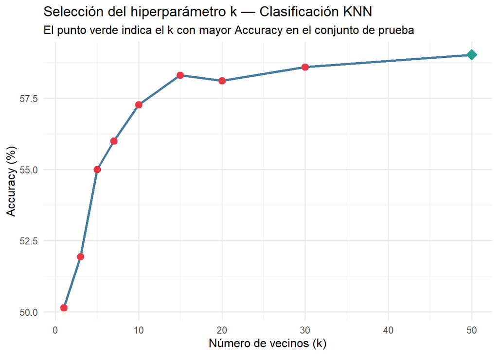

```
## Mejor k seleccionado para clasificación: 50
```

### 5. Eficiencia del Modelo — Métricas de Clasificación KNN

```
## === MATRIZ DE CONFUSIÓN - KNN CLASIFICACIÓN (k = 50 ) ===
```

```
##             Reference
## Prediction   Cara Económica Intermedia
##   Cara       3770       441       1692
##   Económica   608      4595       1994
##   Intermedia 1390      1598       2762
```

```
##
## Accuracy global: 59.03 %
```

```
## Kappa:           0.3843
```

### 6. Matriz de Confusón

Métricas por categoría — KNN Clasificación (k=50)

|  | Categoría | Sensibilidad | Especificidad | F1_Score |
| --- | --- | --- | --- | --- |
| Class: Cara | Class: Cara | 65.36 | 83.70 | 64.60 |
| Class: Económica | Class: Económica | 69.26 | 78.70 | 66.44 |
| Class: Intermedia | Class: Intermedia | 42.83 | 75.91 | 45.29 |

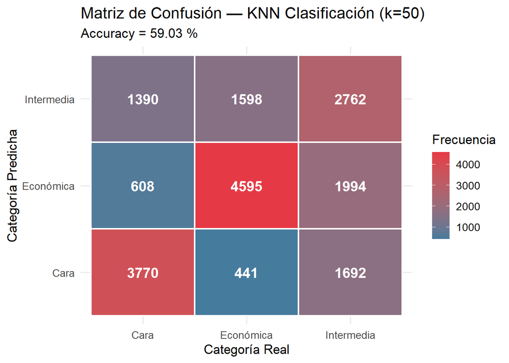

#### Interpretación de los Resultados de Clasificación

**Accuracy global:** El Accuracy indica el porcentaje de propiedades correctamente clasificadas sobre el total del conjunto de prueba. Para KNN de clasificación, este valor refleja qué tan bien el algoritmo distingue entre propiedades Económicas, Intermedias y Caras usando la similitud en el espacio de características.

#### Comparación con los Modelos de Clasificación Anteriores

Comparación de Accuracy entre modelos de clasificación

| Modelo | Accuracy (%) |
| --- | --- |
| Árbol de Decisión | 75.30 |
| Random Forest | 82.10 |
| Naive Bayes | 55.33 |
| KNN (k=50) | 59.03 |

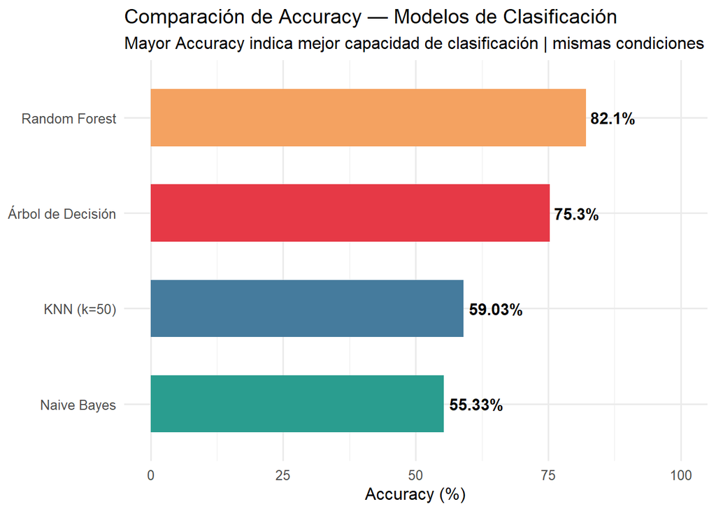

### 7. Análisis del Modelo ¿Puede estar sobreajustado?

Para comprobar la existencia de sobreajuste es necesario evaluar el rendimiento del modelo sobre los mismos datos con el conjunto de entrenamiento y compararlo con su rendimiento en conjunto de prueba.

```
## Accuracy TRAIN (Entrenamiento): 61.13 %
```

```
## Accuracy TEST  (Prueba):        59.03 %
```

Al analizar las métricas obtenidas, observamos que la exactitud en el conjunto de entrenamiento (61.13%) es muy cercana a la obtenida en el conjunto de prueba (59.03%). Esta mínima diferencia es completamente normal y esperada lo que nos permite concluir con seguridad que el modelo no está sobreajustado

Dado que nuestro modelo seleccionó $k = 50$ como el valor óptimo en pasos anteriores, el algoritmo está tomando decisiones basadas en un consenso amplio de 50 propiedades vecinas. Esto suaviza enormemente las fronteras de decisión e impide que el modelo memorice casos atípicos

### 8. Validación Cruzada

Aplicaremos Validación Cruzada de 10 pliegues (10-fold CV) manteniendo nuestro $k=50$.

```
## Resultados de Validación Cruzada (10 Folds) para k = 50
```

```
##    k Accuracy     Kappa  AccuracySD    KappaSD
## 1 50 0.596531 0.3936736 0.006951017 0.01046486
```

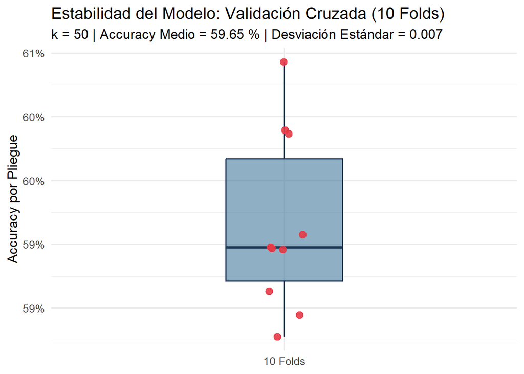

#### ¿Cuál funcionó mejor?

El modelo evaluado con validación cruzada de 10 pliegues arrojó un Accuracy promedio de 59.65%, lo cual es un resultado extraordinariamente consistente con el 59.03% obtenido mediante el método de validación simple evaluado en el punto 5.

Al observar la desviación estándar de la exactitud de 0.0069, es decir, apenas un 0.69%, comprobamos que el rendimiento del algoritmo es sumamente estable dependiendo de qué porción de los datos se utilice para entrenar o probar, confirmando definitivamente que nuestra partición 70/30 inicial fue representativa y estuvo libre de sesgos.

Aunque ambos enfoques funcionaron prácticamente igual de bien en términos de resultados predictivos, el modelo respaldado por Validación Cruzada es metodológicamente superior ya que nos brinda la certeza estadística de que la capacidad de clasificación de nuestro modelo KNN es robusta y constante frente a las variaciones naturales del mercado

### 9. Tuneo de Hiperparámetros

Se utilizó una muestra representativa de 2,500 observaciones aleatorias y una Validación Cruzada de 3 pliegues. Esto garantizó la viabilidad del tiempo de procesamiento sin comprometer la representatividad estadística del mercado

Mejores Hiperparámetros encontrados mediante Grid Search

| Tarea | Vecinos_k | Distancia | Kernel |
| --- | --- | --- | --- |
| Regresión (Predicción de Precio) | 10 | Manhattan (P=1) | rectangular |
| Clasificación (Categoría) | 50 | Euclidiana (P=2) | optimal |

### 10. Métrica de distancia y valor de p

En el proceso de tuneo de hiperparámetros realizado mediante `kknn`, se obtuvieron las siguientes configuraciones óptimas:

- **Regresión:** k = 10, distancia = Manhattan (p = 1), kernel = rectangular
- **Clasificación:** k = 50, distancia = Euclidiana (p = 2), kernel = optimal

A partir de estos resultados, se puede analizar por qué estas configuraciones fueron las más adecuadas para el problema.

El parámetro **p** define la métrica de distancia utilizada en el algoritmo KNN: - **p = 1** corresponde a la distancia Manhattan - **p = 2** corresponde a la distancia Euclidiana

La distancia Manhattan resultó ser más adecuada en el contexto del dataset, ya que calcula la distancia como la suma de diferencias absolutas entre variables, lo que la hace más robusta frente a valores extremos (*outliers*). Esto es particularmente importante en el mercado de Airbnb, donde existen propiedades de lujo con precios significativamente más altos que el promedio, generando alta dispersión en los datos.

Por otro lado, la distancia euclidiana penaliza más las diferencias grandes debido al uso de cuadrados, lo que puede amplificar el impacto de estas observaciones extremas y afectar negativamente la calidad de las predicciones.

- Valores pequeños de k generan modelos muy sensibles al ruido (*alta varianza*).
- Valores grandes de k suavizan las predicciones, reduciendo la varianza y mejorando la generalización.

Dado que el dataset presenta alta variabilidad entre propiedades, utilizar un mayor número de vecinos permite obtener predicciones más estables y representativas del comportamiento general del mercado.

Ahora bien, el uso del kernel **optimal** permite asignar mayor peso a los vecinos más cercanos, lo que mejora la precisión del modelo al priorizar observaciones más relevantes dentro del conjunto de vecinos seleccionados.

### 11. Comparación de eficiencia entre algoritmos

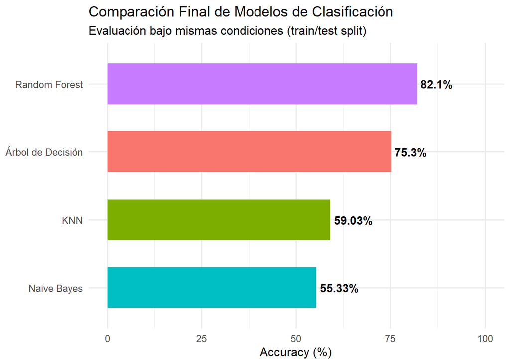

Como se observa en la Figura anterior, el modelo de **Random Forest** presenta el mejor desempeño con un accuracy de **82.1%**, seguido por el **Árbol de Decisión** con **75.3%**. Por su parte, el modelo **KNN** alcanza un accuracy de **59.03%**, mientras que **Naive Bayes** obtiene el menor rendimiento con **55.33%**.

Esta comparación visual permite identificar claramente las diferencias de desempeño entre los modelos bajo las mismas condiciones de entrenamiento y prueba, garantizando una evaluación justa.

El mejor desempeño de **Random Forest** se debe a su capacidad para capturar relaciones no lineales complejas y combinar múltiples árboles de decisión, lo que le permite modelar de forma más efectiva la interacción entre variables como número de habitaciones, capacidad, baños y calificaciones.

El **Árbol de Decisión**, aunque también captura relaciones no lineales, es más sensible a la variabilidad de los datos y tiende a generalizar menos que Random Forest, lo que explica su desempeño intermedio.

En el caso de **KNN**, su rendimiento inferior se debe a que el algoritmo basa sus predicciones en la cercanía entre observaciones. En un dataset con alta variabilidad y presencia de outliers, como el mercado de Airbnb, los vecinos más cercanos no siempre pertenecen a la misma categoría, especialmente en la clase intermedia, lo que genera errores de clasificación.

Ahora bien, **Naive Bayes** presenta el menor desempeño debido a su supuesto de independencia entre variables, el cual no se cumple en este contexto, ya que muchas de las variables están correlacionadas.

Aunque no se midió explícitamente el tiempo de ejecución en este experimento, se puede inferir el comportamiento computacional de los modelos:

- **KNN** es el más costoso en predicción, ya que debe calcular distancias contra todos los datos en cada nueva observación.
- **Random Forest** requiere mayor tiempo de entrenamiento, pero es eficiente en predicción.
- **Árbol de Decisión** es rápido tanto en entrenamiento como en predicción.
- **Naive Bayes** es el más eficiente computacionalmente.

**Conclusión:**

A partir del análisis comparativo, se concluye que **Random Forest es el modelo más adecuado para este problema**, ya que logra el mayor nivel de precisión y demuestra una alta capacidad para capturar relaciones complejas entre variables. Esto es especialmente relevante en el contexto del mercado de Airbnb, donde el precio depende de múltiples factores que no se comportan de forma lineal.

El **Árbol de Decisión** representa una alternativa viable cuando se prioriza la interpretabilidad, mientras que **KNN**, aunque útil para identificar patrones locales, presenta limitaciones debido a la variabilidad del dataset y su costo computacional.

El **Naive Bayes** resulta ser el modelo menos adecuado debido a su supuesto de independencia entre variables.

Los modelos basados en ensambles, como Random Forest, son más robustos y efectivos para problemas reales con alta complejidad, por lo que se recomienda su uso para apoyar la toma de decisiones en SmartStay Advisors.